# Sepsis_Hemosorbtion project, Oleg’s part

Oleg Tarasov

2024-12-04

## Загрузка данных

Данные: `../data/sepsis_HA_df_v2.rds`

Добавлен сквозной уникальный идентификатор пациента `unic_patient_id` в виде `study_id_study_patient_id`

```r
sepsis_HA_df <- readRDS("../data/sepsis_HA_df_v2.rds")

# Создание уникальных идентификаторов

sepsis_HA_df <- sepsis_HA_df %>%
  mutate(unic_patient_id = paste(study_id, study_patient_id, sep = "_"), .after = study_patient_id)
```

## Чистка данных

*Для синхронизации частично использованы наработки Виктории по очистке данных*

### Первичная очистка и трансформация

Создан датасет `sepsis_HA_df_v2_cleaned`, в котором:  
1. удалены строки с `NA` в `treatment` и в `sex` – выбыло 16 пациентов  
2. переменные `character` и `logical` (кроме `study_patient_id`) преобразованы в `factor`  
3. уровни факторов `study_id` и `unic_patient_id` заданы по порядку строк таблицы  
4. приведена в однообразный вид переменная `sex`: (“ж” | “женский”) = “female” & (“м” и “мужской”) = “male”  
5. у пациентки L_mSep_2dC_11_2-07 : `age` == 1990 заменен на 33, `height` == 95 заменен на `NA`  
6. в исследовании CL_Sep_3C_6 рост `height` переведен в см  
7. в `BMI` `NA` заменены на расчетные значения, если есть данные по росту и весу  
8. в `height` `NA` заменены на расчетные значения, если есть данные по ИМТ и весу  
9. из-за неполноты данных убраны показатели острого почечного повреждения: `AKI_T0, AKI_dur_T0_first_end, AKI_first_end_status`  
10. добавлена переменная `combined_efferon` с переименованием: `efferon LPS` | `efferon CT` → `Efferon`, `base` → `Control`

```r
sepsis_HA_df_cleaned <- sepsis_HA_df %>%
  ungroup() %>%
  filter(!is.na(treatment)) %>%
  filter(!is.na(sex)) %>%
  mutate(across(c(study_id, unic_patient_id, time_point, shock_T0, MV_T0, AKI_T0), as.factor)) %>%
  mutate(study_id = fct_inorder(study_id)) %>%
  mutate(unic_patient_id = fct_inorder(unic_patient_id)) %>%
  mutate(sex = recode(sex, "м" = "male", "ж" = "female", "мужской" = "male", "женский" = "female")) %>%
  mutate(
    age = if_else(unic_patient_id == "L_mSep_2dC_11_2-07" & age == 1990, 33, age),
    height = if_else(study_id == "L_mSep_2dC_11_2-07", NA_real_, height)) %>%
  mutate(height = ifelse(study_id == "CL_Sep_3C_6", height * 100, height)) %>%
  mutate(BMI = if_else(is.na(BMI) & !is.na(weight) & !is.na(height), weight / ((height / 100) ^ 2), BMI)) %>%
  mutate(height = if_else(!is.na(BMI) & !is.na(weight) & is.na(height), 100*sqrt(weight / BMI) , height)) %>%
  select(everything(), -c(AKI_T0, AKI_dur_T0_first_end, AKI_first_end_status)) %>% # Исключение AKI
  mutate(combined_efferon = case_when(treatment %in% c("efferon LPS", "efferon CT") ~ "Efferon", treatment == "base" ~ "Control"),
         .after = treatment,
         combined_efferon = factor(combined_efferon, levels = c("Efferon", "Control")))
```

### Точка 0

Создан датасет `sepsis_HA_df_time_0`, отфильтрован по точке 0

```r
sepsis_HA_df_time_0 <- sepsis_HA_df_cleaned %>%
    filter(time_point == 0) # %>%
# Исключение оставшихся переменных статуса
#  select(everything(), -c(shock_dur_T0_first_end, shock_first_end_status, ICU_dur_T0_first_end, ICU_first_end_status, MV_dur_T0_first_end, MV_first_end_status))
```

## Общая визуализация данных и анализ пропущенных значений

```r
# Замена информативных NA на затычки в переменных статуса

sepsis_0_status <- sepsis_HA_df_time_0 %>%
  mutate(across(contains("_dur_T0_first_end") | contains("_first_end_status"),
                function(x) x = if_else(is.na(MV_T0) == TRUE, as.character(x), replace_na(as.character(x), "ND"))
                ))

# Вектор и таблица числа пропущенных значений по переменным

count_NA_vector <- sort(colSums(is.na(sepsis_0_status)))
count_NA_tibble <- tibble(`variables` = names(count_NA_vector),
                   `NA_count` = count_NA_vector)
```

```r
## Отрисовка тепловой карты NA с помощью ggplot2

# Создаем функции для модификации данных и отрисовки тепловой карты

NA_tibble <- function(df, exclude = c("study_id", "study_patient_id", "unic_patient_id"), ...) {
  NA_tibble <- df %>%
  select(order(colSums(is.na(.)))) %>%
  mutate( across( !{{exclude}}, function(x) x %>% is.na() ) )  %>%
  pivot_longer(cols = !{{exclude}},
               cols_vary = "slowest",
               names_to = "var",
               values_to = "is.NA") %>%
  mutate(var = fct_rev(fct_inorder(factor(var, ordered=TRUE))))
  return(NA_tibble)
}

heatmap_NA <- function(NA_tibble = NA_tibble,
                       x = unic_patient_id,
                       y = var,
                       fill = is.NA,
                       fill_color = c("TRUE" = "lightgrey", "FALSE" = "darkgrey"),
                       ...) {
  ggheatmap <- NA_tibble %>%
    ggplot() +
    geom_tile(aes({{x}}, {{y}}, fill = {{fill}})) +
  scale_fill_manual(values = {{fill_color}}) +
  scale_y_discrete(name = NULL) +
  theme_bw()
  return(ggheatmap)
}
```

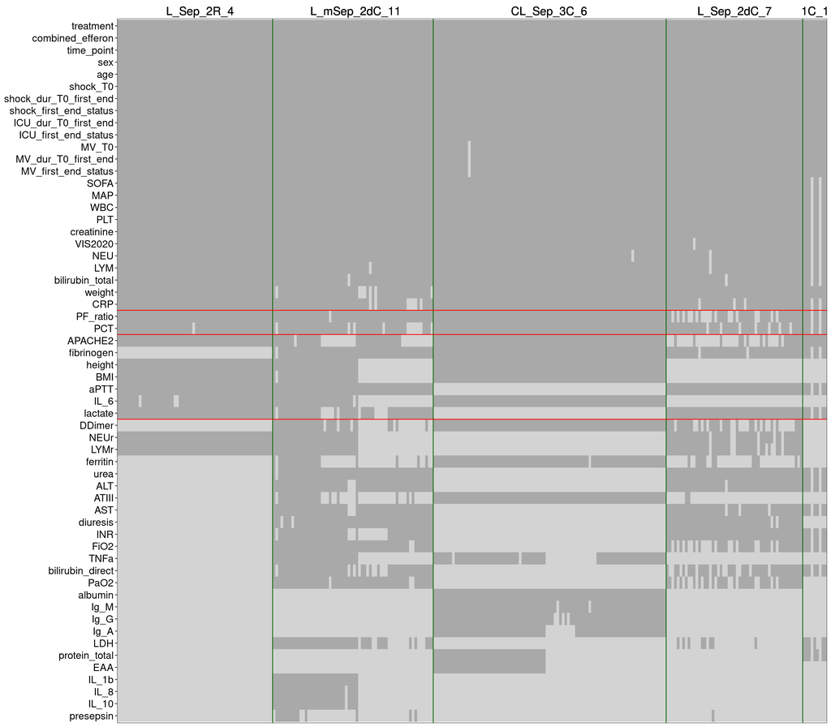

```r
sepsis_NA_tibble <- sepsis_0_status %>% NA_tibble()
sepsis_ggheatmap_base <- sepsis_NA_tibble %>% heatmap_NA()

#

study_vlines <- c()
for (i in 1:5) {
  study_vlines <- c(study_vlines,
    which.max(sepsis_NA_tibble$study_id == levels(sepsis_NA_tibble$study_id)[i])
    )
}

sepsis_ggheatmap <- sepsis_ggheatmap_base +
  geom_vline(xintercept = study_vlines[-1] - 0.5,
             linewidth = 0.5,
             colour = "darkgreen") +
  geom_hline(yintercept = which(levels(sepsis_NA_tibble$var) %in% c("CRP", "PCT", "lactate"))-0.5,
           linewidth = 0.5,
             colour = "red") +
  scale_x_discrete(name = NULL,
                   breaks = sepsis_NA_tibble$unic_patient_id[study_vlines],
                   labels = c(levels(sepsis_NA_tibble$study_id)[-5], "1C_1"),
                   position = "top") +
  theme(legend.position='none',
        axis.ticks.x=element_blank(),
        axis.text.x = element_text(hjust = c(-0.7,-0.4,-1,-0.4,0.1), size = 16, color = "black"),
        axis.text.y = element_text(size = 14, color = "black")
        )

sepsis_ggheatmap
```

```r
# ggsave("./figures/var_vs_study_NAs_time_0.png", sepsis_ggheatmap, height = 14, width = 16, dpi = 120, units = "in")
```

```r
#

sepsis_HA_df_time_0 %>%
  select(where(is.numeric)) %>%
  # select(!contains("_dur_T0_first_end")) %>%
  select(any_of(names(count_NA_vector[count_NA_vector <= 25]))) %>%
ggpairs()
```

[output not shown]

## Анализ главных компонент

```r
# Отсечка по CRP включительно -- остается 243 пациента

sepsis_pca <- sepsis_HA_df_time_0 %>%
  select(is.numeric) %>%
  select(where(function(x) sum(is.na(x)) <13)) %>%
  na.omit()

sepsis_pca_result <- prcomp(sepsis_pca, scale = T)

summary(sepsis_pca_result)
```

```
## Importance of components:
##                           PC1    PC2    PC3     PC4     PC5     PC6    PC7
## Standard deviation     1.5444 1.2873 1.2514 1.12613 1.06149 0.98073 0.9430
## Proportion of Variance 0.1835 0.1275 0.1205 0.09755 0.08667 0.07399 0.0684
## Cumulative Proportion  0.1835 0.3109 0.4314 0.52895 0.61562 0.68961 0.7580
##                           PC8     PC9    PC10    PC11    PC12    PC13
## Standard deviation     0.8780 0.86146 0.81385 0.75656 0.62276 0.10159
## Proportion of Variance 0.0593 0.05709 0.05095 0.04403 0.02983 0.00079
## Cumulative Proportion  0.8173 0.87439 0.92534 0.96937 0.99921 1.00000
```